# F1Data slides

### **Formula 1 Data** - Matteo Zuliani

#### Motivazioni:

- Interesse personale
- Innovazione e tecnologia
- Aspetti Storici e Culturali:

#### Domande che mi sono posto

- Quali sono i piloti con più campionati?
- Chi sono i piloti con più vittorie?
- Quali sono le nazionalità che hanno dato luce a più piloti?
- Quanti campioni ci sono stati nella storia della F1?
- Quali sono i piloti con più pole position?
- Quali sono i decenni che hanno visto correre il maggior numero di piloti?
- Quali piloti hanno il maggior numero di anni di carriera?
- Quali sono i piloti più efficienti dalla pole position?

### I dati utilizzati

##### È stato utilizzato un dataset contenente le informazioni sui piloti di Formula 1

#### Cosa contiene il dataset?

- Carriera dei piloti
- Performance nelle stagioni
- Status di campione

#### Dati mancanti

- Dettagli sulle auto
- Dettagli sugli stipendi

#### Disponibilità

- Il dataset è disponibile online su Kaggle. Può trovarlo [qui.](https://www.kaggle.com/datasets/petalme/f1-drivers-dataset)

#### Vediamo il grafico rappresentante i 10 piloti con più campionati vinti

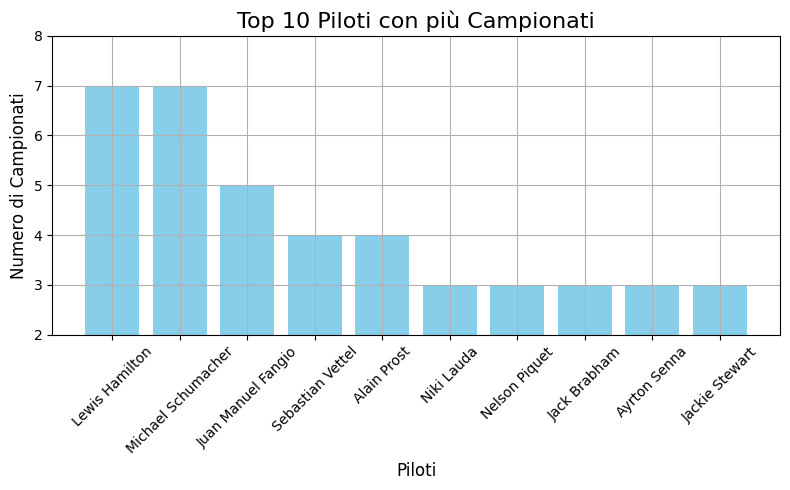

#### Che pilota ha vinto più gare?

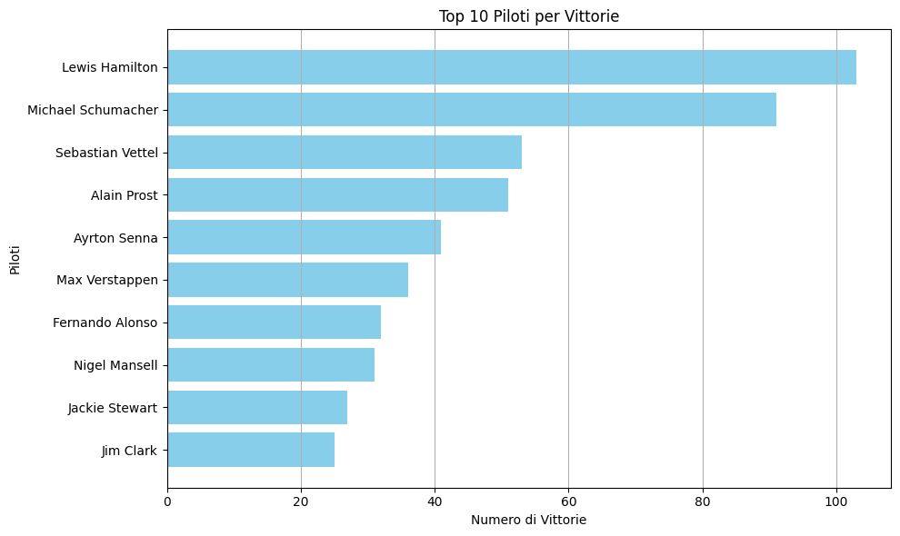

##### Lewis Hamilton possiede il maggior numero di vittorie nella F1, con 103 successi

#### Vediamo la rappresentazione grafica delle nazioni che hanno dato luce a più piloti

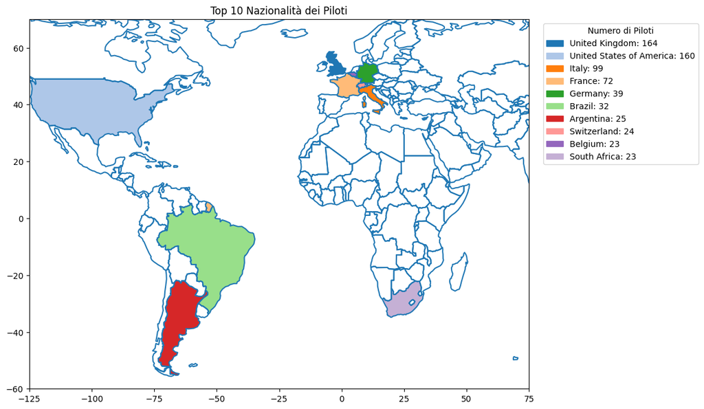

###### Vediamo che il Regno Unito ha contribuito alla formazione del maggior numero di piloti

#### Quanti piloti sono stati campioni durante la storia della F1?

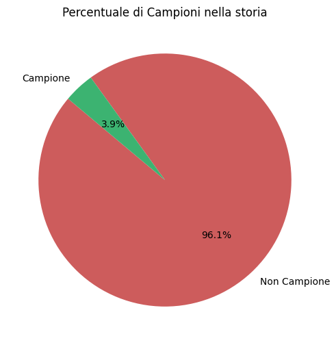

##### Vediamo che sul totale di piloti, il 3,9% ha vinto un campionato

#### Quale pilota conduce la classifica delle pole position?

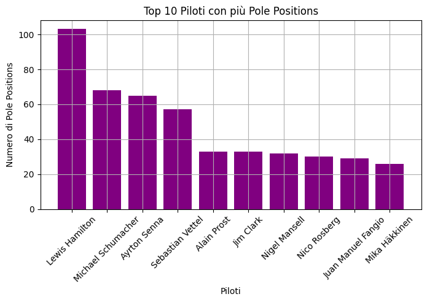

##### Lewis Hamilton è in testa alla classifica con 103 pole position

#### Quale decennio ha visto gareggiare il maggior numero di piloti?

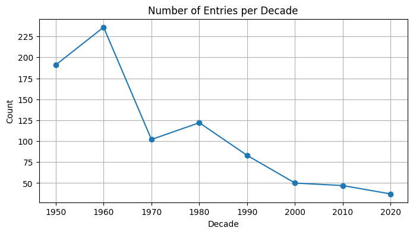

##### il decennio 1960-1970 ha visto il maggior numero di piloti della storia, dovuto soprattutto all'espansione dello sport

#### Top 10 piloti per anni di attività

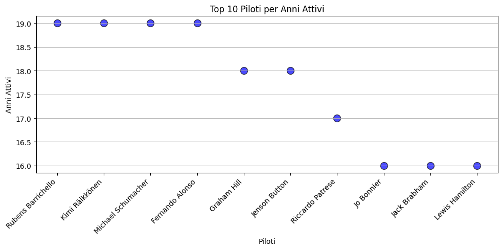

##### Barrichello, Räikkönen, Schumacher e Alonso sono i piloti con più anni attivi

#### Top 5 piloti per efficienza sulle Pole Position

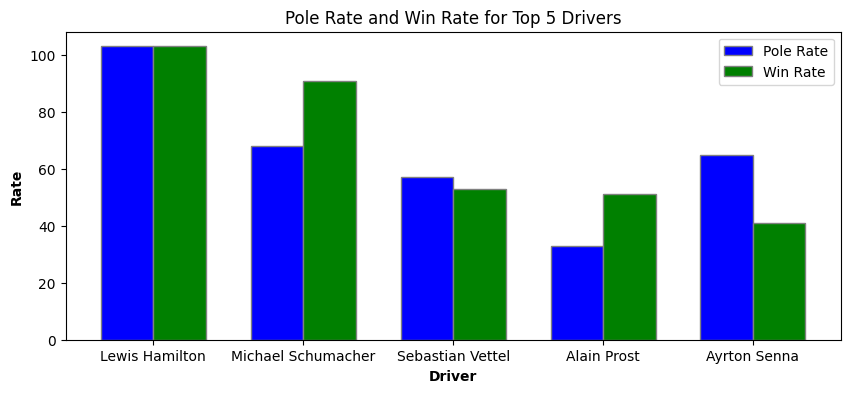